# Estudios de Informática, Multimedia y Telecomunicaciones

# 8 REPRESENTACIÓN GRÁFICA DE LOS RESULTADOS A PARTIR DE TABLAS Y GRÁFICAS

Existen diferentes gráficas para usar como modelos de prediccion. Uno de ellos es el arbol de decisión el cual se busca predecir la probabilidad de que se llegue el objetivo en base a ciertas condiciones. Usamos en nuestro caso para representar los resultados, un arbol de decisión el cual al comienzo transforma la variable survived para que a partir de sexo puede ir ramificandose la resolución al problema.

Gráficamos con rpart.plot el arbol de desición donde se puede varios niveles.

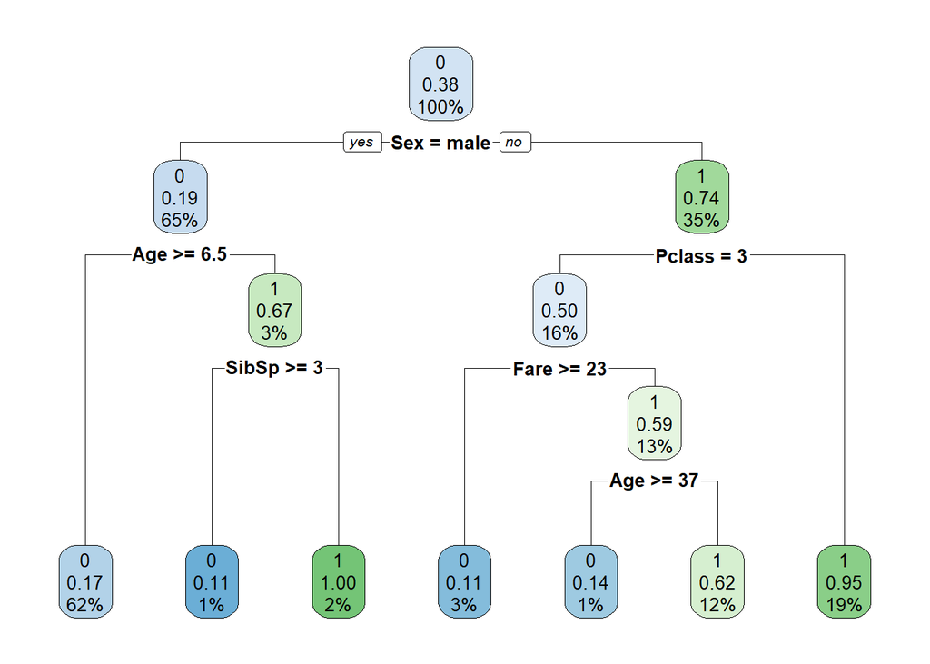

```r
# Representamos el arbol de decision
model_dt<- rpart(Survived ~.,data=train, method="class")
rpart.plot(model_dt)
```

Como quedaría el arbol:

```r
# Vemos como queda el arbol
model_dt
```

```
## n= 891
##
## node), split, n, loss, yval, (yprob)
##       * denotes terminal node
##
##  1) root 891 342 0 (0.61616162 0.38383838)
##    2) Sex=male 577 109 0 (0.81109185 0.18890815)
##      4) Age>=6.5 553  93 0 (0.83182640 0.16817360) *
##      5) Age< 6.5 24   8 1 (0.33333333 0.66666667)
##       10) SibSp>=2.5 9   1 0 (0.88888889 0.11111111) *
##       11) SibSp< 2.5 15   0 1 (0.00000000 1.00000000) *
##    3) Sex=female 314  81 1 (0.25796178 0.74203822)
##      6) Pclass=3 144  72 0 (0.50000000 0.50000000)
##       12) Fare>=23.35 27   3 0 (0.88888889 0.11111111) *
##       13) Fare< 23.35 117  48 1 (0.41025641 0.58974359)
##         26) Age>=36.5 7   1 0 (0.85714286 0.14285714) *
##         27) Age< 36.5 110  42 1 (0.38181818 0.61818182) *
##      7) Pclass=1,2 170   9 1 (0.05294118 0.94705882) *
```

Podemos tambien exportar los resultados de la predicción en un archivo csv.

```r
pred.test <- predict(model,test)
pred.test <- ifelse(pred.test > 0.5,1,0)

pred.test
```

```
##  892  893  894  895  896  897  898  899  900  901  902  903  904  905  906  907
##    0    0    0    0    0    0    1    0    1    0    0    0    1    0    1    1
##  908  909  910  911  912  913  914  915  916  917  918  919  920  921  922  923
##    0    0    0    0    0    0    1    1    1    0    1    0    0    0    0    0
##  924  925  926  927  928  929  930  931  932  933  934  935  936  937  938  939
##    0    0    0    0    0    1    0    0    0    0    0    1    1    0    0    0
##  940  941  942  943  944  945  946  947  948  949  950  951  952  953  954  955
##    1    0    0    0    1    1    0    0    0    0    0    1    0    0    0    1
##  956  957  958  959  960  961  962  963  964  965  966  967  968  969  970  971
##    1    1    1    0    0    1    1    0    0    0    1    1    0    1    0    1
##  972  973  974  975  976  977  978  979  980  981  982  983  984  985  986  987
##    0    0    0    0    0    0    1    1    1    0    0    0    1    0    0    0
##  988  989  990  991  992  993  994  995  996  997  998  999 1000 1001 1002 1003
##    1    0    1    0    1    0    0    0    1    0    0    0    0    0    0    1
## 1004 1005 1006 1007 1008 1009 1010 1011 1012 1013 1014 1015 1016 1017 1018 1019
```

[output cut: 39 more lines]

```r
test$Survived<- pred.test

write.csv(pred.test,file="prediction.csv",row.names = F)
```

Tambien se exporta el archivo ya limpio.

```r
write.csv(dfaux,file="archivolimpio.csv",row.names = F)
```

# 9 RESOLUCIÓN DE PROBLEMAS Y CONCLUSIONES

Con el uso de arboles de decisión para la resolución de nuestro problema en cuanto a la sobrevivencia de los pasajeros y el impacto de ciertas variables en ella, hemos encontrado que nos trae los siguientes resultados comprendidos en varios niveles:

- si es hombre (male) y tiene una edad Age>=6.5 entonces muere
- Si es hombre (male) y tiene una edad Age< 6.5 y SibSp>=2.5 entonces muere
- Si es hombre (male) y tiene una edad Age< 6.5 y SibSp<2.5 entonces sobrevive
- si es mujer (female) y pclass< 3 entonces sobrevive
- si es mujer (female), Pclass=3, Fare>=23.35, entonces muere
- si es mujer (female), Pclass=3, Fare< 23.35, Age>=36.5 entonces muere
- si es mujer (female), Pclass=3, Fare< 23.35, Age< 36.5 entonces sobrevive

# 10 EXPORTACIÓN DEL CÓDIGO

En el github se puede observar el archivo subido con el código realizado en el programa r. Tambien se encuentra en el github los archivos csv de los dataset, el dataset limpio y el de las predicciones.

- Mejia Quintero Dayana: https://github.com/danamejia1810/Practica-2-Titanic-dataset.git
- Peterson Christopher: https://github.com/christopherapeterson/Practica-2-Titanic-dataset.git

# 11 BIBLIOGRAFÍA

- Calvo M, Subirats L, Pérez D (2019). Introducción a la limpieza y análisis de los datos. Editorial UOC.
- Dalgaard, Peter (2008). Introductory statistics with R. Springer Science & Business Media.
- Jiawei Han, Micheine Kamber, Jian Pei (2012). Data mining: concepts and techniques. Morgan Kaufmann.
- Osborne, Jaso W. (2010). Data Cleaning Basics: Best Practices in Dealing with Extreme Scores. Newborn and Infant Nursing Reviews; 10 (1): pp. 1527-3369.
- Squire, Megan (2015). Clean Data. Packt Publishing Ltd.
- Wes McKinney (2012). Python for Data Analysis. O’Reilley Media, Inc.